# index

### Introduction

For our final project, we are interesting in investigating datasets that are related to education in the United States. We chose to work with these topics because we realize that there are many disparities in quality of education between different areas and communities throughout the US and we think that it would be valuable to draw correlations between factors - and possibly figure out if certain connected factors cause these disparities. The dataset that we are using comes from Roy Garrard, from the website [Kaggle.com](https://www.kaggle.com/noriuk/us-education-datasets-unification-project), and includes data such as Revenue, Academic Achievement, and Enrollment, which is also broken down further into race and gender. Titled **U.S. Education Datasets: Unification Project**, the data is aggregated from multiple .gov sites, such as The Nation’s Report Card, The US Census Bureau, and the National Center for Education Statistics.

### Summary

Within the summary, the values were chosen in order to investigate a correlation with revenue (or funding) with the values, such as test scores, that would reflect quality of education. The statistics we looked at werethe total number of observations present in our data set,the highest total revenue spent on a single state, the highest total expenditure spent on a single state, the total expenditure of the state with the highest 8th grade reading score, and the state with the lowest attendance. Calling upon `summary_info` gives us the variables and values.

We can see that from our `1715` observations, the largest total revenue (`8.9217262\times 10^{7}`) is greater than the total expenditure (`8.5320133\times 10^{7}`), and that there seems to be funding being used in that state, and that the highest reading score in the 8th grade seems to be paired with a high expenditure of `1.6201905\times 10^{7}`. The region with the lowest attendance would be the `DISTRICT_OF_COLUMBIA`.

### Various Charts

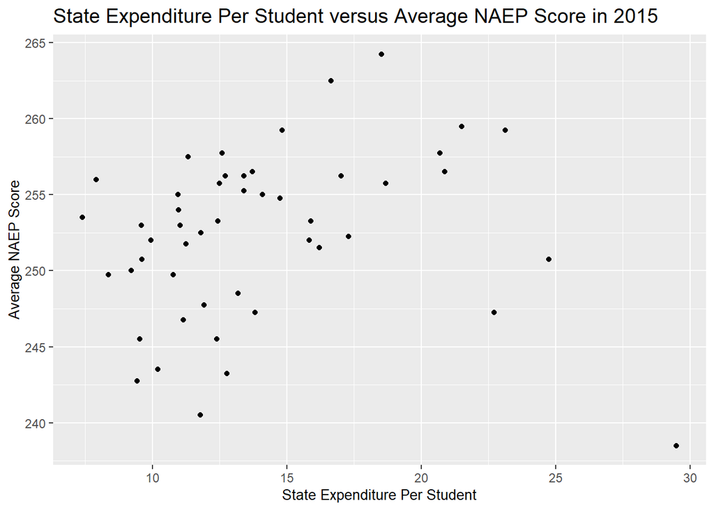

This chart was created in order to show the relationship between state expenditure per student and average national test scores in math and reading. We see through our visualization that, although there seems to be a vague positive correlation between the expenditure and test scores, there correlation itself is not extremely strong and there are many outliers.

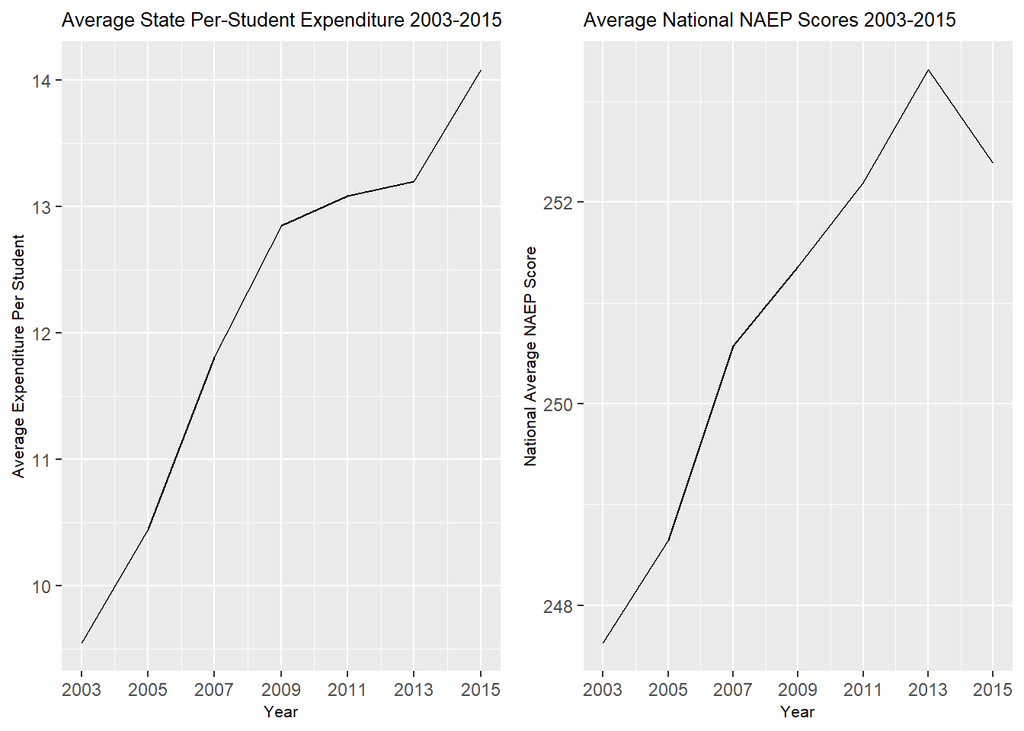

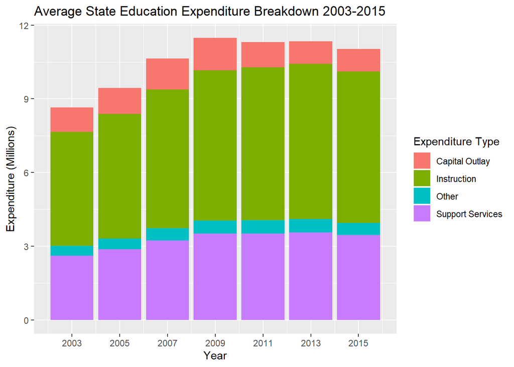

### Our Table

The table was included to represent the data in a more organized and condensed manner, only including the columns that are needed or need to be specified. The information that the table reveals includes records of the columns. The columns include state, year, total revenue, total expenditure, all students in the state, average reading 4 score, average reading 8 score, average math 4 score, average math 8 score.

| STATE | YEAR | TOTAL_REVENUE | TOTAL_EXPENDITURE | ALL_STUDENTS | AVG_READING_4_SCORE | AVG_READING_8_SCORE | AVG_MATH_4_SCORE | AVG_MATH_8_SCORE | TOTAL_EXPENDITURE < 1e+07 |
| --- | --- | --- | --- | --- | --- | --- | --- | --- | --- |
| ALABAMA | 1992 | 2678885 | 2653798 | 731634 | 207 | NA | 208 | 252 | TRUE |
| ALASKA | 1992 | 1049591 | 972488 | 122487 | NA | NA | NA | NA | TRUE |
| ARIZONA | 1992 | 3258079 | 3401580 | 673477 | 209 | NA | 215 | 265 | TRUE |
| ARKANSAS | 1992 | 1711959 | 1743022 | 441490 | 211 | NA | 210 | 256 | TRUE |
| CALIFORNIA | 1992 | 26260025 | 27138832 | 5254844 | 202 | NA | 208 | 261 | FALSE |
| COLORADO | 1992 | 3185173 | 3264826 | 612635 | 217 | NA | 221 | 272 | TRUE |
| CONNECTICUT | 1992 | 3834302 | 3721338 | 488476 | 222 | NA | 227 | 274 | TRUE |
| DELAWARE | 1992 | 645233 | 638784 | 104321 | 213 | NA | 218 | 263 | TRUE |
| DISTRICT_OF_COLUMBIA | 1992 | 709480 | 742893 | 80937 | 188 | NA | 193 | 235 | TRUE |
| FLORIDA | 1992 | 11506299 | 11305642 | 1981407 | 208 | NA | 214 | 260 | FALSE |
| GEORGIA | 1992 | 5536901 | 5535942 | 1207186 | 212 | NA | 216 | 259 | TRUE |
| HAWAII | 1992 | 996809 | 1040121 | 177448 | 203 | NA | 214 | 257 | TRUE |
| IDAHO | 1992 | 859329 | 886161 | 231668 | 219 | NA | 222 | 275 | TRUE |
| ILLINOIS | 1992 | 9748650 | 9850560 | 1873567 | NA | NA | NA | NA | TRUE |
| INDIANA | 1992 | 5060274 | 5182754 | 960630 | 221 | NA | 221 | 270 | TRUE |
| IOWA | 1992 | 2663934 | 2795774 | 494839 | 225 | NA | 230 | 283 | TRUE |
| KANSAS | 1992 | 2245348 | 2234915 | 451536 | NA | NA | NA | NA | TRUE |
| KENTUCKY | 1992 | 2642902 | 2518082 | 655041 | 213 | NA | 215 | 262 | TRUE |
| LOUISIANA | 1992 | 3341253 | 3362853 | 797985 | 204 | NA | 204 | 250 | TRUE |
| MAINE | 1992 | 1206819 | 1228869 | 216453 | 227 | NA | 232 | 279 | TRUE |
| MARYLAND | 1992 | 4658498 | 4698374 | 751850 | 211 | NA | 217 | 265 | TRUE |
| MASSACHUSETTS | 1992 | 5517659 | 5245560 | 859948 | 226 | NA | 227 | 273 | TRUE |
| MICHIGAN | 1992 | 9963137 | 10170688 | 1603610 | 216 | NA | 220 | 267 | FALSE |
| MINNESOTA | 1992 | 4684684 | 4981125 | 793724 | 221 | NA | 228 | 282 | TRUE |
| MISSISSIPPI | 1992 | 1684706 | 1691990 | 506668 | 199 | NA | 202 | 246 | TRUE |
| MISSOURI | 1992 | 4043682 | 4197600 | 859357 | 220 | NA | 222 | 271 | TRUE |
| MONTANA | 1992 | 828983 | 781009 | 160011 | NA | NA | NA | NA | TRUE |
| NEBRASKA | 1992 | 1542413 | 1534046 | 282414 | 221 | NA | 225 | 278 | TRUE |
| NEVADA | 1992 | 1097076 | 1251651 | 222974 | NA | NA | NA | NA | TRUE |
| NEW_HAMPSHIRE | 1992 | 1063391 | 1066647 | 181247 | 228 | NA | 230 | 278 | TRUE |

[output cut: 1685 more lines]